# Project: Expectation Maximization Algorithm

Victor Apatu

2024-12-11

The Expectation-Maximization (E-M) Algorithm is an iterative method for finding the maximum likelihood estimates (MLE) of parameters in statistical models where the data is incomplete, has missing values, or involves latent variables. the EM model simply operates on bayesian assumption by finding a latent missing variable given what has been observed.

### How Does it Work?

#### Bayesian Assumption

The EM algorithm assumes a probabilistic framework, treating missing or latent variables as random variables drawn from a specific distribution, by estimating the posterior probability of the latent variables given the observed data.

The E-M model can be largely be classified in two (2) main steps:

### The E-step (Expectation)

1. Calculate the expected value of the latent variables based on the current parameter estimates: Think of this as “filling in” the missing data using conditional probabilities.
   $$Q(\theta | \theta^{(t)}) = \mathbb{E}_{Z | X, \theta^{(t)}} \left[ \log
   P(X, Z | \theta) \right].$$

#### The M-step (Maximization)

2. Update the parameter estimates by maximizing the expected log-likelihood:
   $$\theta^{(t+1)} = \arg \max_\theta Q(\theta | \theta^{(t)}).$$
3. Reapeat step 1 and 2 until it converges.

### Example 1

Lets consider a simple example where $Y_1, Y_2 \sim \text{i.i.d. Exp}(\theta)$. Suppose $y_1 = 5$ is observed but the value $y_2$ is missing. The complete-data log likelihood function is

$$\log f_Y(y|\theta) = 2 \log \{\theta\} - \theta y_1 - \theta y_2.$$

Taking the conditional expectation of $\log L(\theta|Y)$ yields

$$Q(\theta|\theta^{(t)}) = 2 \log \{\theta\} - 5\theta - \theta E[Y_2|y_1,
\theta^{(t)}],$$

By independence, $E[Y_2|y_1, \theta^{(t)}] = E[Y_2|\theta^{(t)}] = 1 / \theta^{(t)}$ . The maximizer of $Q(\theta|\theta^{(t)})$ with respect to $\theta$ is easily found to be the root of

$$2 / \theta - 5 - 1 / \theta^{(t)} = 0.$$

Solving for $\theta$ provides the updating equation

$$\theta^{(t+1)} = 2 \theta^{(t)} / (5 \theta^{(t)} + 1).$$

### For the traditional MLE Approach

#### Results

```
## EM Algorithm:
```

```
## Estimated theta: 0.2000012
```

```
## Number of iterations: 18
```

```
## Traditional MLE:
```

```
## Estimated theta: 0.2
```

### Gaussian Mixed Model

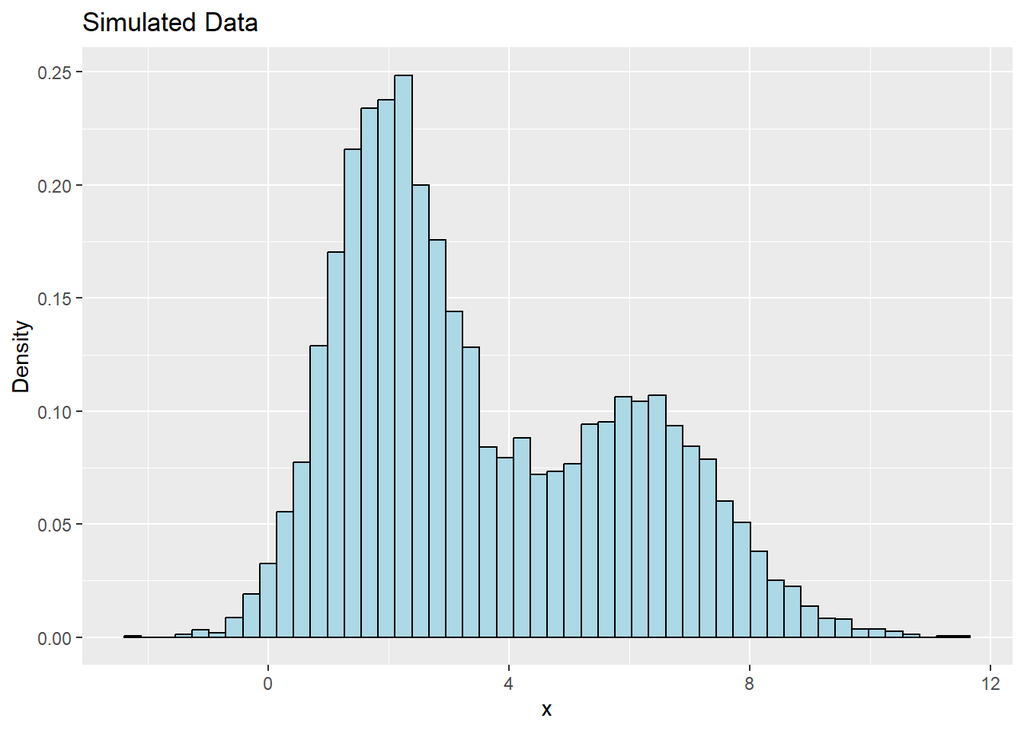

```
## Converged in 84 iterations
```

```
## Final Estimates:
```

```
## Mixing Proportions: 0.605 0.395
```

```
## Means: 1.996 6.026
```

```
## Standard Deviations: 0.997 1.511
```

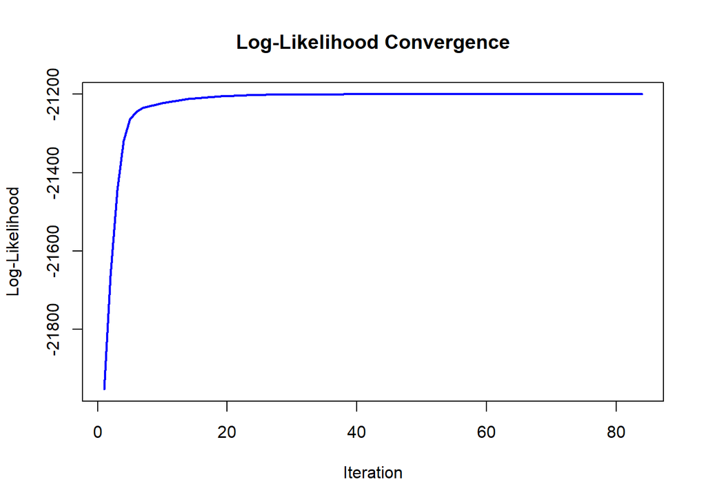

### Variance Covariance Estimation

The E-M Algorithm can be used to find the maximum likelihood estimator (MLE) but it does not directly estimate the variance-covariance matrix of the MLEs. The E-M algorithm relies heavily on asymptotic normality of the MLEs to estimate the variance covariance matrix. In Bayesian methods the Hessian matrix provides a good foundation for the estimation of the variance covariance matrix.

#### The Hessian Approach

```
##
## Variance-Covariance Matrix (Hessian):
```

```
##               [,1]          [,2]          [,3]          [,4]          [,5]
## [1,]  9.549597e-05 -3.502555e-05  8.537454e-05  0.0002264402  5.620862e-05
## [2,] -3.502555e-05  7.455514e-05 -8.537518e-05 -0.0002264419 -5.620904e-05
## [3,]  8.537454e-05 -8.537518e-05  3.828770e-04  0.0005362058  1.508683e-04
## [4,]  2.264402e-04 -2.264419e-04  5.362058e-04  0.0020658919  3.421879e-04
## [5,]  5.620862e-05 -5.620904e-05  1.508683e-04  0.0003421879  1.938029e-04
## [6,] -1.466964e-04  1.466975e-04 -3.295882e-04 -0.0009912181 -2.004480e-04
##               [,6]
## [1,] -0.0001466964
## [2,]  0.0001466975
## [3,] -0.0003295882
## [4,] -0.0009912181
## [5,] -0.0002004480
## [6,]  0.0009821870
```

### Example 3: Old Faithful Dataset

This is a dataset that contains 272 observations of eruptions from the Old Faithful geyser in Yellowstone National Park, USA. The dataset consists of two key variables:

1. Eruption Duration: The duration (in minutes) of each geyser eruption.
2. Waiting Time: The waiting time (in minutes) between successive eruptions.

In this case we are interested in X =waiting time

$X$: Waiting time

$p$: Probability of shorter waiting time

$\theta = (p, \mu_1, \mu_2, \sigma_1, \sigma_2)$

$f(x \mid \theta) = p \mathcal{N}(\mu_1, \sigma_1) + (1-p) \mathcal{N}(\mu_2, \sigma_2)$

$Y_i = \begin{cases} 1 & \text{if shorter waiting time,} \\ 0 & \text{otherwise} \end{cases}$ $Y_i \sim \text{Bernoulli}(p)$ and $Y_i$ is missing

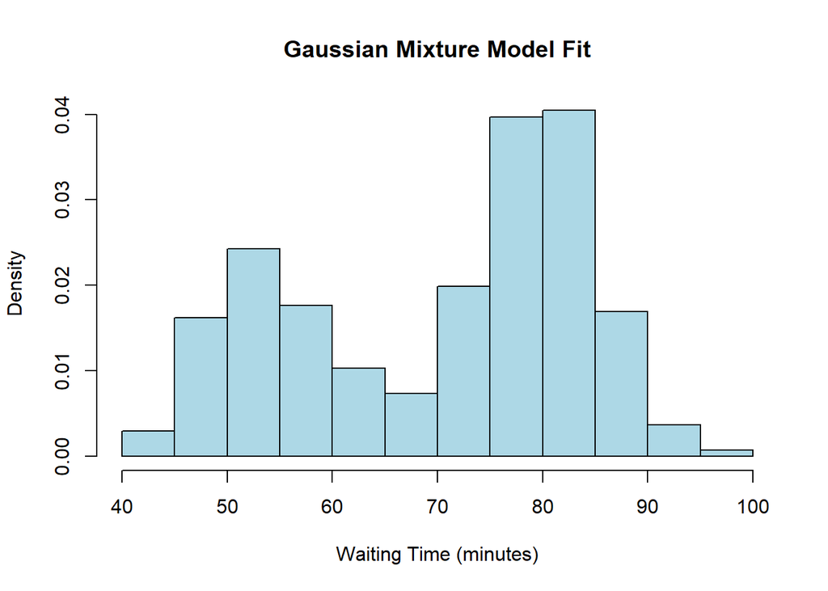

```
## Converged in 1522 iterations
```

```
## Final Estimates:
```

```
## Mixing Proportions: 0.349 0.651
```

```
## Means: 64.298 74.438
```

```
## Standard Deviations: 14.338 12.898
```

### Covariance Estimation

```
##
## Covariance Matrix (Hessian):
```

```
##             [,1]        [,2]      [,3]       [,4]       [,5]        [,6]
## [1,]  0.05498277 -0.05369874  1.359042  0.1073731  0.1534783  0.04663065
## [2,] -0.05369874  0.05609117 -1.359041 -0.1073730 -0.1534782 -0.04663062
## [3,]  1.35904156 -1.35904066 28.241762  7.1814079  2.2333452 -2.08709354
## [4,]  0.10737308 -0.10737301  7.181408 -1.2411766  1.1929368  1.84671378
## [5,]  0.15347834 -0.15347823  2.233345  1.1929368  1.6051747 -0.69880905
## [6,]  0.04663065 -0.04663062 -2.087094  1.8467138 -0.6988091 -0.53879089
```

#### Reference

Givens, G. H., & Hoeting, J. A. (2012). Computational statistics. John Wiley & Sons.